# Dijkstra's Shortest Path Algorithm

## Instructions

Welcome to the Dijkstra's Shortest Path Finder! This program utilizes Dijkstra's algorithm to find the shortest path between two airports from a provided dataset.

### How to Run:

1. **Start the Program:**
   - Launch the program by running it with Python: `python program.py`
2. **Input Airport Codes:**
   - You will be prompted to enter the IATA airport code for the origin airport.
   - After entering the origin, you will be prompted to enter the IATA airport code for the destination airport.
3. **View the Shortest Path:**
   - The program will display the shortest path from the origin to the destination airport along with the total travel distance.
4. **Repeat or Quit:**
   - After displaying the shortest path, you can continue to find another path by entering new airport codes.
   - To exit the program, type 'Q' when prompted for the origin airport code.

### Limitations:

- **Airport Data:**
  - The program is currently limited to the airports and routes defined in the provided dataset.
  - Some airports or routes may not be available, which would result in the program indicating that the destination is unreachable.
  - If you want to try different datasets, you will have to go into the code and change which csv file it is supposed to open
- **Dataset Accuracy:**
  - The distances are calculated using the Haversine formula based on airport latitude and longitude. As such, the actual travel distance may vary due to real-world factors such as air traffic control restrictions, flight patterns, and more.
- **Performance:**
  - While the program is optimized for smaller datasets, performance may degrade with extremely large datasets or complex route networks.

### **Example Running with Small Dataset:**

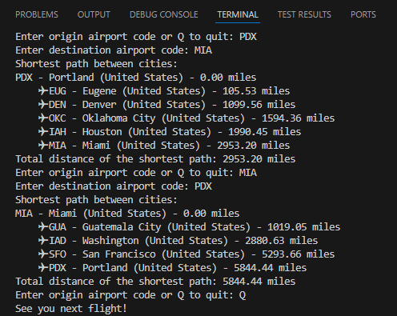

### **Example Running with Large Dataset:**

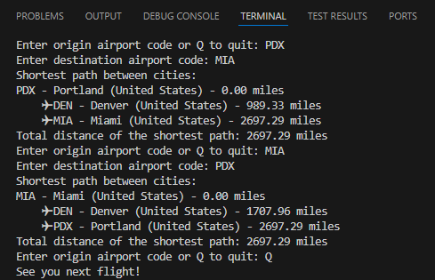

```python
import csv
from typing import Any, NamedTuple
from datastructures.graph import Graph
from haversine import haversine, Unit

class Airport(NamedTuple):
    id: int
    name: str
    code: str
    city: str
    country: str
    latitude: float
    longitude: float

class Flight():
    def __init__(self, origin: Airport, destination: Airport) -> None:
        self._origin: Airport = origin
        self._destination: Airport = destination

    @property
    def weight(self) -> float:
        origin = (self._origin.latitude, self._origin.longitude)
        destination = (self._destination.latitude, self._destination.longitude)
        return haversine(origin, destination, Unit.MILES)

    def __lt__(self, object: Any) -> bool:
        if not isinstance(object, Flight):
            return False

        return self.weight < object.weight


def read_csv(filename: str) -> Graph:
    graph = Graph()

    csv_reader = csv.DictReader(open(filename, newline="\n", encoding="utf-8-sig"))

    for row in csv_reader:
        origin = Airport(
            int(row['origin_airport_id']),
            row['origin_airport'],
            row['origin_airport_code'],
            row['origin_city'],
            row['origin_country'],
            float(row['origin_airport_latitude']),
            float(row['origin_airport_longitude']))

        destination = Airport(
            int(row['destination_airport_id']),
            row['destination_airport'],
            row['destination_airport_code'],
            row['destination_city'],
            row['destination_country'],
            float(row['destination_airport_latitude']),
            float(row['destination_airport_longitude']))

        flight = Flight(origin, destination)
        weight = flight.weight
        graph.add_edge(origin, destination, flight, weight)

    return graph

# def compare_edges() -> None:
#     graph = Graph()

#     seattle = Airport()
#     portland = Airport()
#     olympia = Airport()

#     flight1 = Flight(seattle, portland)
#     flight2 = Flight(seattle, olympia)
#     flight3 = Flight(olympia, portland)

#     graph.add_edge(seattle, portland, flight1, flight1.weight)
#     graph.add_edge(seattle, olympia, flight2, flight2.weight)
#     graph.add_edge(olympia, portland, flight3, flight3.weight)


#     seattle_outbound = graph.edges_from(seattle)

#     seattle_outbound = sorted(seattle_outbound)


def demo_sort():

    airport1 = Airport(1, "Portland", "PDX", "Portland, OR", "USA", 45.58869934,-122.5979996)
    airport2 = Airport(2, "Seattle", "SEA", "Seattle, WA", "USA", 47.44900131,-122.3089981)
    airport3 = Airport(3, "San Francisco", "SFO", "San Francisco, CA", "USA", 37.61899948,-122.375)

    flight1 = Flight(airport1, airport2)
    flight2 = Flight(airport1, airport3)
    flight3 = Flight(airport3, airport2)
    flight4 = Flight(airport2, airport3)
    flight5 = Flight(airport2, airport1)
    flight6 = Flight(airport3, airport1)

    distance = [flight1.weight,
                flight2.weight,
                flight3.weight,
                flight4.weight,
                flight5.weight,
                flight6.weight]

    print(sorted(distance, key=lambda x: x))


def dijkstra(graph: Graph, source: Airport, destination: Airport) -> tuple[list, float]:
    distances = {airport: float('inf') for airport in graph.vertices}
    distances[source] = 0
    previous_nodes = {airport: None for airport in graph.vertices}

    unvisited = set(graph.vertices)
    current_vertex = source

    while unvisited:
        current_vertex = min((v for v in unvisited if v in distances), key=lambda x: distances[x], default=None)

        if current_vertex is None or distances[current_vertex] == float('inf'):
            break

        unvisited.remove(current_vertex)

        # Process each edge starting from current_vertex
        for flight in graph.edges_from(current_vertex):
            neighbor = flight._destination
            weight = flight.weight

            if neighbor in unvisited:
                new_distance = distances[current_vertex] + weight
                if new_distance < distances[neighbor]:
                    distances[neighbor] = new_distance
                    previous_nodes[neighbor] = current_vertex

    # Construct shortest path from source to destination
    path = []
    step = destination
    if distances[destination] == float('inf'):
        return [], float('inf')  # Early exit if destination is unreachable

    while step is not None:
        path.append(step)
        step = previous_nodes[step]
    path.reverse()

    return path, distances[destination]



def get_airport_by_input(graph, input_str):
    # Try to match by airport code directly
    matched_airports = [airport for airport in graph.vertices if airport.code.lower() == input_str.lower()]

    if len(matched_airports) == 1:
        return matched_airports[0]
    elif len(matched_airports) > 1:
        print("Multiple airports found:")
        for idx, airport in enumerate(matched_airports, start=1):
            print(f"{idx}. {airport.name} ({airport.code}) - {airport.city}, {airport.country}")
        selection = int(input("Please select the correct airport by number: ")) - 1
        return matched_airports[selection]
    else:
        print("No matching airport found.")
        return None

def main():
    graph = read_csv("routes.csv")

    while True:  # Continuously ask for input until the user decides to quit
        origin_input = input("Enter origin airport code or Q to quit: ")
        if origin_input.lower() == 'q':
            print("See you next flight!")
            break

        destination_input = input("Enter destination airport code: ")

        origin_airport = get_airport_by_input(graph, origin_input)
        destination_airport = get_airport_by_input(graph, destination_input)

        if not origin_airport or not destination_airport:
            print("Origin or destination airport not correctly identified.")
            continue  # Prompt again for input

        shortest_path, total_distance = dijkstra(graph, origin_airport, destination_airport)

        # Output
        print("Shortest path between cities:")
        cumulative_distance = 0.0
        previous_airport = None
        for index, airport in enumerate(shortest_path):
            if index == 0:
                print(f"{airport.code} - {airport.city} (United States) - 0.00 miles")
            else:
                leg_distance = dijkstra(graph, previous_airport, airport)[1]
                cumulative_distance += leg_distance
                print(f"    ✈ {airport.code} - {airport.city} (United States) - {cumulative_distance:.2f} miles")
            previous_airport = airport
        print("Total distance of the shortest path:", f"{total_distance:.2f}", "miles")




if __name__ == "__main__":
    main()
```

Github repository for code: https://github.com/Willamette-University-SCIS/cs152-assignments-repo-RealSaltKing/releases/tag/Version1.0Dijkstra

```python
!jupyter nbconvert --to html dijkstra.ipynb
```